# Assignment #2 - Classification

**Due: Oct 15 (Tuesday) 11:00 pm**

Amit Shetty

# I. Introduction

Describe the objective of this assignment. You can briefly state how you accompilsh it.

The objective of this assignment is to implement machine learning classification algorithms using 4 different techniques.

1. Pocket Algorithm
2. Linear Discriminant Analysis (LDA)
3. Quadratic Discriminant Analysis (QDA)
4. Logisitc Regression

I will be implenting each of these techniques using python and numpy with functions that are able to train the model and apply the model to the test data. To ensure that the model works correctly, I will be splitting the data into training and test sets and training the model on the training set and testing the model's accuracy on the test set. I will be doing so for all the methods described above. To test the results visually I will be plotting the resutls using a scatter plot. Class labels will be differentiated using colors.

# II. Data

Introduce your data and visualize them. Describe your observations about the data. You can reuse the data that you examined in Assignment #0 (of course for classification).

From the UCI website, extraction was done by Barry Becker from the 1994 Census database.

```python
import pandas as pd
import numpy as np
import matplotlib.pyplot as plt
import seaborn as sns
```

```python
dataset = pd.read_csv('adult.data.csv')
```

```python
dataset.info()
```

```
<class 'pandas.core.frame.DataFrame'>
RangeIndex: 32560 entries, 0 to 32559
Data columns (total 15 columns):
39                32560 non-null int64
 State-gov        32560 non-null object
 77516            32560 non-null int64
 Bachelors        32560 non-null object
 13               32560 non-null int64
 Never-married    32560 non-null object
 Adm-clerical     32560 non-null object
 Not-in-family    32560 non-null object
 White            32560 non-null object
 Male             32560 non-null object
 2174             32560 non-null int64
 0                32560 non-null int64
 40               32560 non-null int64
 United-States    32560 non-null object
 <=50K            32560 non-null object
dtypes: int64(6), object(9)
memory usage: 3.7+ MB
```

Since there are not headers in the data file provided we will be getting that information from the dataset description posted on https://archive.ics.uci.edu/ml/datasets/Census+Income

```python
header_cols = ['age', 'workclass', 'fnlwgt', 'education', 'education.num', 'marital.status', 'occupation', 'relationship',
              'race', 'sex', 'capital.gain', 'capital.loss', 'hours.per.week', 'native.country', 'income']

dataset = pd.read_csv('adult.data.csv', names = header_cols)
```

```python
dataset.info()
```

```
<class 'pandas.core.frame.DataFrame'>
RangeIndex: 32561 entries, 0 to 32560
Data columns (total 15 columns):
age               32561 non-null int64
workclass         32561 non-null object
fnlwgt            32561 non-null int64
education         32561 non-null object
education.num     32561 non-null int64
marital.status    32561 non-null object
occupation        32561 non-null object
relationship      32561 non-null object
race              32561 non-null object
sex               32561 non-null object
capital.gain      32561 non-null int64
capital.loss      32561 non-null int64
hours.per.week    32561 non-null int64
native.country    32561 non-null object
income            32561 non-null object
dtypes: int64(6), object(9)
memory usage: 3.7+ MB
```

```python
dataset.head()
```

|  | age | workclass | fnlwgt | education | education.num | marital.status | occupation | relationship | race | sex | capital.gain | capital.loss | hours.per.week | native.country | income |
| --- | --- | --- | --- | --- | --- | --- | --- | --- | --- | --- | --- | --- | --- | --- | --- |
| 0 | 39 | State-gov | 77516 | Bachelors | 13 | Never-married | Adm-clerical | Not-in-family | White | Male | 2174 | 0 | 40 | United-States | <=50K |
| 1 | 50 | Self-emp-not-inc | 83311 | Bachelors | 13 | Married-civ-spouse | Exec-managerial | Husband | White | Male | 0 | 0 | 13 | United-States | <=50K |
| 2 | 38 | Private | 215646 | HS-grad | 9 | Divorced | Handlers-cleaners | Not-in-family | White | Male | 0 | 0 | 40 | United-States | <=50K |
| 3 | 53 | Private | 234721 | 11th | 7 | Married-civ-spouse | Handlers-cleaners | Husband | Black | Male | 0 | 0 | 40 | United-States | <=50K |
| 4 | 28 | Private | 338409 | Bachelors | 13 | Married-civ-spouse | Prof-specialty | Wife | Black | Female | 0 | 0 | 40 | Cuba | <=50K |

There are certain columns that contains symbols such as '?' in the data which serve no purpose and need to be dropped.

```python
dataset['workclass'] = dataset['workclass'].apply(lambda x: x.strip())
dataset['occupation'] = dataset['occupation'].apply(lambda x: x.strip())
dataset['native.country'] = dataset['native.country'].apply(lambda x: x.strip())
dataset = dataset[dataset['workclass']!= '?']
dataset = dataset[dataset['occupation']!= '?']
dataset = dataset[dataset['native.country']!= '?']
dataset.info()
```

```
<class 'pandas.core.frame.DataFrame'>
Int64Index: 30162 entries, 0 to 32560
Data columns (total 15 columns):
age               30162 non-null int64
workclass         30162 non-null object
fnlwgt            30162 non-null int64
education         30162 non-null object
education.num     30162 non-null int64
marital.status    30162 non-null object
occupation        30162 non-null object
relationship      30162 non-null object
race              30162 non-null object
sex               30162 non-null object
capital.gain      30162 non-null int64
capital.loss      30162 non-null int64
hours.per.week    30162 non-null int64
native.country    30162 non-null object
income            30162 non-null object
dtypes: int64(6), object(9)
memory usage: 3.7+ MB
```

There are certain columns in the dataset that can be converted to categories. This will reduce the size of the dataset and make it easier to process the data with columns that actually reflect the status of the target variable.

```python
# There are certain attirbutes here that can be categorised
dataset[['workclass','education','marital.status', 'occupation', 'relationship', 'race', 'sex', 'native.country']] = dataset[['workclass','education','marital.status', 'occupation', 'relationship', 'race', 'sex', 'native.country']].apply(pd.Categorical)
```

```python
dataset.info()
```

```
<class 'pandas.core.frame.DataFrame'>
Int64Index: 30162 entries, 0 to 32560
Data columns (total 15 columns):
age               30162 non-null int64
workclass         30162 non-null category
fnlwgt            30162 non-null int64
education         30162 non-null category
education.num     30162 non-null int64
marital.status    30162 non-null category
occupation        30162 non-null category
relationship      30162 non-null category
race              30162 non-null category
sex               30162 non-null category
capital.gain      30162 non-null int64
capital.loss      30162 non-null int64
hours.per.week    30162 non-null int64
native.country    30162 non-null category
income            30162 non-null object
dtypes: category(8), int64(6), object(1)
memory usage: 2.1+ MB
```

The income column in this case will be our target variable. The goal is to determine which factors (columns) in this case contribute to the target variable

```python
# The income is our target variable since we are trying to determine who earned more than $50k
dataset['income'].value_counts()
```

```
 <=50K    22654
 >50K      7508
Name: income, dtype: int64
```

Since the income column is our target variable we have to preprocess and clean the data then convert the string to a dummy integer that can be easily processed.

```python
# Preparing target variable

dataset['income'] = dataset['income'].astype(str)
dataset['income'] = dataset['income'].apply(lambda x: x.strip())
dataset['income'] = dataset['income'].apply(lambda x: 1 if x == '>50K' else 0)
dataset['income'] = dataset['income'].astype(int)
dataset['income'].value_counts()
```

```
0    22654
1     7508
Name: income, dtype: int64
```

Cleaning the data for further processing

```python
dataset['workclass']=dataset['workclass'].apply(lambda x: x.strip())
dataset['education']=dataset['education'].apply(lambda x: x.strip())
dataset['marital.status']=dataset['marital.status'].apply(lambda x: x.strip())
dataset['occupation']=dataset['occupation'].apply(lambda x: x.strip())
dataset['relationship']=dataset['relationship'].apply(lambda x: x.strip())
dataset['race']=dataset['race'].apply(lambda x: x.strip())
dataset['sex']=dataset['sex'].apply(lambda x: x.strip())
```

```python
dataset.head()
```

|  | age | workclass | fnlwgt | education | education.num | marital.status | occupation | relationship | race | sex | capital.gain | capital.loss | hours.per.week | native.country | income |
| --- | --- | --- | --- | --- | --- | --- | --- | --- | --- | --- | --- | --- | --- | --- | --- |
| 0 | 39 | State-gov | 77516 | Bachelors | 13 | Never-married | Adm-clerical | Not-in-family | White | Male | 2174 | 0 | 40 | United-States | 0 |
| 1 | 50 | Self-emp-not-inc | 83311 | Bachelors | 13 | Married-civ-spouse | Exec-managerial | Husband | White | Male | 0 | 0 | 13 | United-States | 0 |
| 2 | 38 | Private | 215646 | HS-grad | 9 | Divorced | Handlers-cleaners | Not-in-family | White | Male | 0 | 0 | 40 | United-States | 0 |
| 3 | 53 | Private | 234721 | 11th | 7 | Married-civ-spouse | Handlers-cleaners | Husband | Black | Male | 0 | 0 | 40 | United-States | 0 |
| 4 | 28 | Private | 338409 | Bachelors | 13 | Married-civ-spouse | Prof-specialty | Wife | Black | Female | 0 | 0 | 40 | Cuba | 0 |

Plot overview to show how many people have higher income. Based on the plot below it seems many people have lower incomes

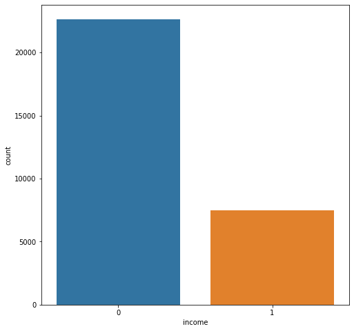

```python
fig,ax = plt.subplots(figsize=(8, 8))
sns.countplot(dataset['income'],label="Income Variable Count")
plt.show()
```

The following bar graph shows how marital status has been distributed in the census. Based on the plot below we can see being married and living with the spouse were the poeple that were included in the census.

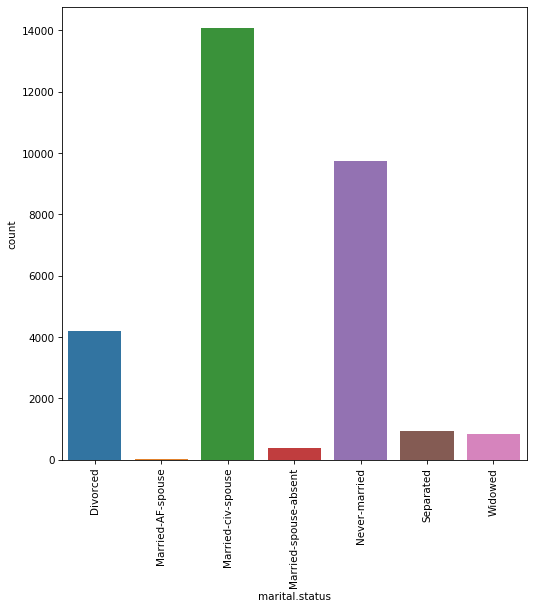

```python
fig,ax = plt.subplots(figsize=(8, 8), dpi=75)
sns.countplot(dataset['marital.status'],label="Marital Status")
plt.xticks(rotation=90)
plt.show()
```

The following bar grpah shows the occupation the people had whent he census was taken. Based on the graph below the census has been fairly even amonst poeple craft repairsmen, managerial positions and professors.

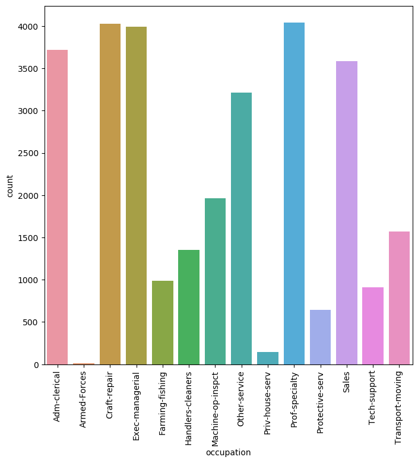

```python
fig,ax = plt.subplots(figsize=(8, 8), dpi=100)
sns.countplot(dataset['occupation'],label="Occupation")
plt.xticks(rotation=90)
plt.show()
```

The following graph shows a breakdown of the people who directly took the survey and what their role was with respect to the whole family. It seems more men took the census than women since the highest number is amogst husbands.

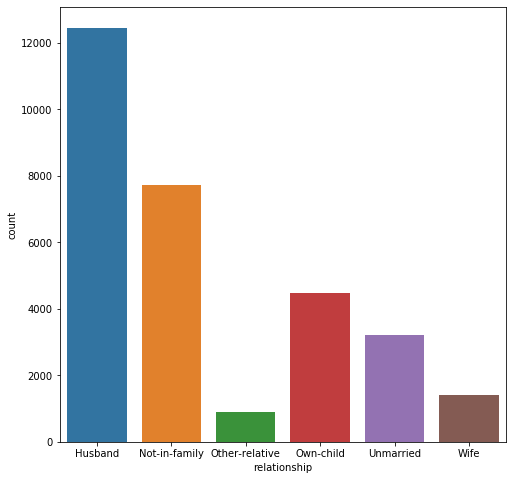

```python
fig,ax = plt.subplots(figsize=(8, 8))
sns.countplot(dataset['relationship'],label="Relationship")
plt.show()
```

The plot shows the distribution for race that was taken during the census. It shows whites were the most populous race that took part in the census

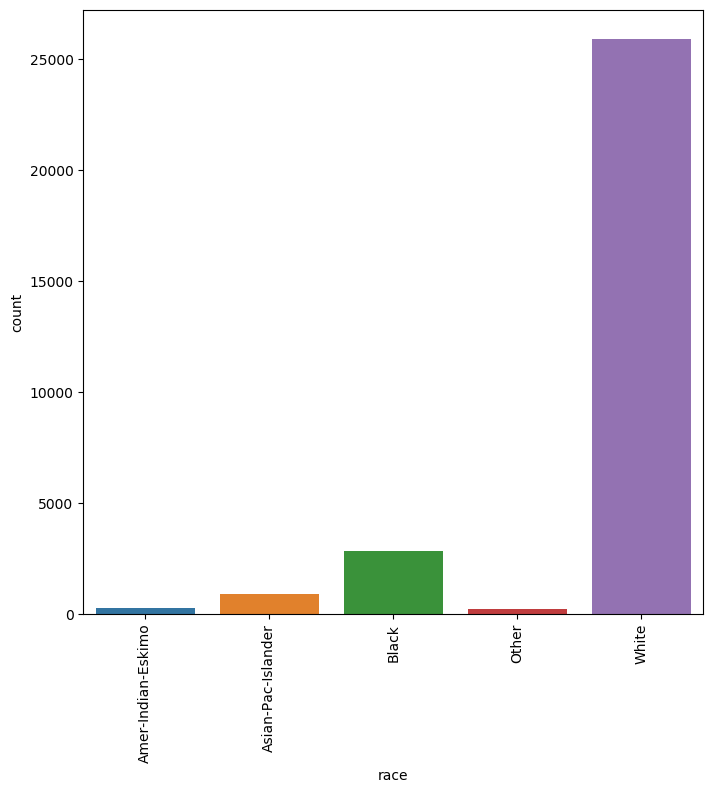

```python
fig,ax = plt.subplots(figsize=(8, 8), dpi=100)
sns.countplot(dataset['race'],label="Race")
plt.xticks(rotation=90)
plt.show()
```

Not plotting native country wise since most of the people are from the United States.

The following graph shows what workclass hs the highest disparity with regards to income. It seems surporsingly that people working in the private sector had in both cases of the target label high and low incomes.

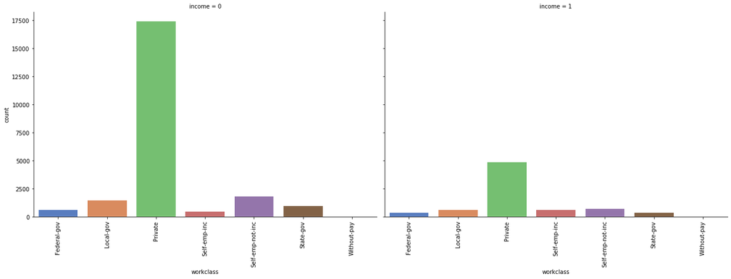

```python
plt.figure(figsize=(12,12))
g = sns.catplot(x="workclass", col="income", data=dataset, aspect=1.5,
                height=6, kind="count", palette="muted")
g.set_xticklabels(rotation=90)
plt.show()
```

The plot shows the distribution of wealth based on the occupation of the person. The largest number of people having the lowest income are from clerical, craft repair and other services whereas in the obvious cases, those with the highest incomes are either managers or speciality professors.

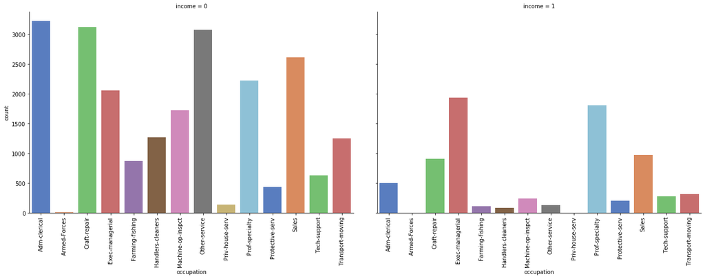

```python
plt.figure(figsize=(12,12))
g = sns.catplot(x="occupation", col="income", data=dataset, aspect=1.5,
                height=6, kind="count", palette="muted")
g.set_xticklabels(rotation=90)
plt.show()
```

The graph shows which sex had the highest capital gains in the sensus. Based on the observaitons it seems males had the highest.

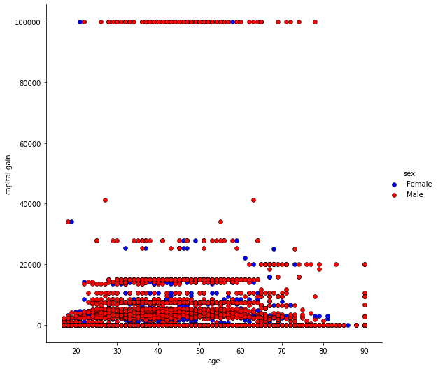

```python
dataset['sex'] = dataset['sex'].apply(lambda x:x.strip())

sns.pairplot(dataset, x_vars=["age"], y_vars=["capital.gain"], height=7.5,
                  hue="sex", palette={"Male": "red", "Female": "blue"},
                  plot_kws=dict(edgecolor="k", linewidth=0.5))
plt.show()
```

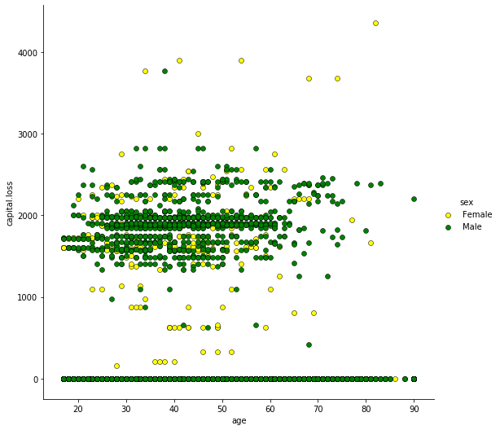

```python
sns.pairplot(dataset, x_vars=["age"], y_vars=["capital.loss"], size=7.5,
                  hue="sex", palette={"Male": "green", "Female": "yellow"},
                  plot_kws=dict(edgecolor="k", linewidth=0.5))
plt.show()
```

Since we are focussing on multiple input parameter that define the target variable, we will be showing data in a 3D graph. The following 3D graph combines the capital loss and capital gain against the age of the population in a 3d model to better depict multiple parameters.

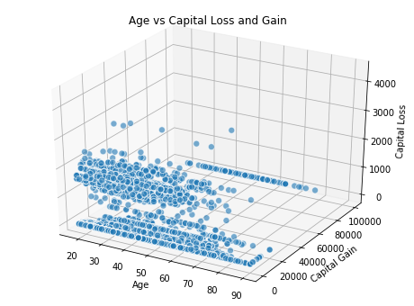

```python
from mpl_toolkits.mplot3d import Axes3D

fig = plt.figure(figsize=(8, 6))
ax = fig.add_subplot(111, projection='3d')

xs = dataset['age']
ys = dataset['capital.gain']
zs = dataset['capital.loss']
ax.scatter(xs, ys, zs, s=50, alpha=0.6, edgecolors='w')

ax.set_xlabel('Age')
ax.set_ylabel('Capital Gain')
ax.set_zlabel('Capital Loss')

ax.set_title('Age vs Capital Loss and Gain')

plt.show()
```

Finally, we will be scanning all numerical columns to see how they relate and affect each other. To do so we will be creating a summayr pairplot.

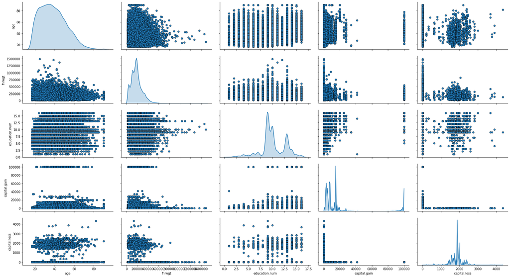

```python
# Using only numerical columns since they can compared to easily

numerical_cols = ['age', 'fnlwgt', 'education.num', 'capital.gain', 'capital.loss']

sns.pairplot(dataset[numerical_cols],aspect=1.8,
                  plot_kws=dict(edgecolor="k", linewidth=0.5),
                  diag_kind="kde", diag_kws=dict(shade=True))

plt.show()
```

Merging the myriad of multi label columns into simpler terms. Also we will be dropping unncessary columns that do not contribute to the final target variable.

```python
dataset["sex"] = dataset["sex"].map({"Male": 0, "Female":1})


dataset["marital.status"] = dataset["marital.status"].replace(['Never-married','Divorced','Separated','Widowed'], 'Single')
dataset["marital.status"] = dataset["marital.status"].replace(['Married-civ-spouse','Married-spouse-absent','Married-AF-spouse'], 'Married')
dataset["marital.status"] = dataset["marital.status"].map({"Married":1, "Single":0})
dataset["marital.status"] = dataset["marital.status"].astype(int)

dataset.drop(labels=["workclass","education","occupation","relationship","race","native.country"], axis = 1, inplace = True)
print('Dataset with Dropped Labels')
print(dataset.head())
```

```
Dataset with Dropped Labels
   age  fnlwgt  education.num  marital.status sex  capital.gain  capital.loss  \
0   39   77516             13               0   0          2174             0
1   50   83311             13               1   0             0             0
2   38  215646              9               0   0             0             0
3   53  234721              7               1   0             0             0
4   28  338409             13               1   1             0             0

   hours.per.week  income
0              40       0
1              13       0
2              40       0
3              40       0
4              40       0
```

A covariance matrix helps us determine which columns contribute the most to the target variable. In this case we can see that the level of education and martial status play an important role in determining income.

[figure not shown]

```python
fig,ax = plt.subplots(figsize=(8, 8))
g = sns.heatmap(dataset.corr(), ax=ax, annot=True, fmt = ".2f", cmap = "coolwarm")
# Fix for heatmap top and bottom crop issue
# ax.get_ylim()
ax.set_ylim(7.5, 1.0)
plt.show()
```

# III. Method

Summarize the pocket algorithm, discriminant analysis, and logistic regression. The superclass *Classifier* defines common utility methods. Finish the normalize function for you. Do not forget explain your implementation.

The explanation of your codes should not be the comments in a code cell. This section should include

- review of the 4 classification models
- your implementation and description

### A. Super Classs Definition

```python
import numpy as np
from abc import ABC, abstractmethod

# Super class for machine learning models

class BaseModel(ABC):
    """ Super class for ITCS Machine Learning Class"""

    @abstractmethod
    def train(self, X, T):
        pass

    @abstractmethod
    def use(self, X):
        pass



class Classifier(BaseModel):
    """
        Abstract class for classification

        Attributes
        ==========
        meanX       ndarray
                    mean of inputs (from standardization)
        stdX        ndarray
                    standard deviation of inputs (standardization)
    """

    def __init__(self, ):
        self.meanX = None
        self.stdX = None

    def normalize(self, X):
        """ standardize the input X """

        if not isinstance(X, np.ndarray):
            X = np.asanyarray(X)

        self.meanX = np.mean(X, 0)
        self.stdX = np.std(X, 0)

        # TODO: Finish this normalization
        Xs = (X - self.meanX)/self.stdX
        return Xs

    def _check_matrix(self, mat, name):
        if len(mat.shape) != 2:
            raise ValueError(''.join(["Wrong matrix ", name]))

    # add a basis
    def add_ones(self, X):
        """
            add a column basis to X input matrix
        """
        self._check_matrix(X, 'X')
        return np.hstack((np.ones((X.shape[0], 1)), X))

    ####################################################
    #### abstract funcitons ############################
    @abstractmethod
    def train(self, X, T):
        pass

    @abstractmethod
    def use(self, X):
        pass
```

### B. Pocket Algorithm

Pocket Learning Algorithm keeps the best result seen so far in its pocket. The best result means the number of misclassification is minimum. If the new weights produce a smaller number of misclassification than the weights in the pocket, then replace the weights in the pocket to the new weights; if the new weights are not better than the one in the pocket, keep the one in the pocket and discard the new weights. At the end of the training iteration, the algorithm returns the solution in the pocket, rather than the last solution.

Implementation Strategy:

- Initialize the pocket weight vector, w_pocket to 0 and use this weight vector as the initialized weight vector W0
- For each training iteration, perform the following steps
  - Run the training step of perceptron learning algorithm and obtain the updated weight vector
  - Evaluate the above weight by compaing the number of misclassification on the entire sample set with the number of misclassification performed by w_pocket
  - If the weight of the current iteration is better then replace w_pocket with the new weight
- Return the final w_pocket and terminate the session

```python
from copy import deepcopy as copy


class PocketAlgo(Classifier):
    maxiter = 1000
    alpha = 0.1

    def __init__(self, alpha, maxiter):
        Classifier.__init__(self)
        self.alpha = alpha
        self.maxiter = maxiter

    # return 1 if w is better -1 if wp is better
    def compare(self, X, T, w, wp):
        y = np.sign(X @ w)
        yp = np.sign(X @ wp)
        return 1 if np.sum(y == T) >= np.sum(yp == T) else -1

    def train(self, X, T):
        w = np.zeros(3)
        w_pocket = copy(w)
        X1 = self.add_ones(X)
        N = X.shape[0]
        for i in range(self.maxiter):
            converged = True
            for k in range(N):
                y = w @ X1[k]
                if np.sign(y) != np.sign(T[k]):
                    w += self.alpha * T[k] * X1[k]
                    converged = False
                    if self.compare(X1, T, w, w_pocket) > 0:
                        w_pocket[:] = w[:]
            if converged:
                print("converged at ", i)
                return w_pocket
                break
        return w_pocket

    def use(self, X, w_pocket):
        X1 = self.add_ones(X)
        return X1@w_pocket
```

### C. QDA

Discriminant analysis is used to determine which variables discriminate between two or more naturally occurring groups.

QDA (Quadratic Discriminant Analysis) is closely related to linear discriminant analysis (LDA), where it is assumed that the measurements are normally distributed. Unlike LDA however, in QDA there is no assumption that the covariance of each of the classes is identical. To estimate the parameters required in quadratic discrimination more computation and data is required than in the case of linear discrimination. If there is not a great difference in the group covariance matrices, then the latter will perform as well as quadratic discrimination. Quadratic Discrimination is the general form of Bayesian discrimination.

Implementation Strategy

-Input values are normalised using their mean and standard deviation

-The normalised values are then passed to the QDA function which applies the following formula to the data. δk(x)=−0.5ln|Σk|−0.5(x−μk)⊤Σ−1k(x−μk)+lnP(T=k)

-The output is two different quadratic boundary functions which help us plot the decision boundary, by leveraging the contour function.

```python
def QDA(X, mu, sigma, prior):
    sigma_inv = np.linalg.inv(sigma)
    diffv = X - mu
    return -0.5  * np.log(np.linalg.det(sigma)) \
            - 0.5 * np.sum(diffv @ sigma_inv * diffv, axis=1) \
            + np.log(prior)
```

```python
def implement_QDA_class(class1data, class2data, X_test):
    N1 = len(class1data)
    N2 = len(class2data)
    N = len(feature_data)
    mu1 = np.mean(class1data, 0)
    mu2 = np.mean(class2data, 0)
    Sigma1 = np.cov(class1data.T)
    Sigma2 = np.cov(class2data.T)
    prior1 = N1 / N
    prior2 = N2 / N
    xs, ys = np.meshgrid(np.linspace(-3,6, 500), np.linspace(-3,7, 500))
    XtestS = normalize(X_test)
    d1 = QDA(XtestS, mu1, Sigma1, prior1)
    d2 = QDA(XtestS, mu2, Sigma2, prior2)
    scattermethod(X, Y=T_test, N=100)
```

### D. LDA

LDA (Linear Discriminant Analysis) tries to find the linear combination of features which best separates two or more classes of examples. The resulting combination is then used as a linear classifier. LDA has a dependent variable that is categorical (i.e. the class label). LDA is also closely related to principal component analysis (PCA) and factor analysis in that both look for linear combinations of variables which best explain the data. LDA explicitly attempts to model the difference between the classes of data. PCA on the other hand does not take into account any difference in class.

Implementation Strategy

-Input variables are normalised using mean and standard deviation.

-The normalised values are passed to the LDA function which applies the following formula to the data.

$$ \delta_k(\XV) = \XV^\top \boldsymbol\Sigma^{-1} \boldsymbol\mu_k -\frac{1}{2} \boldsymbol\mu_k^\top \boldsymbol\Sigma^{-1}\boldsymbol\mu_k + \ln P(T = k). $$

Ref: https://docs.rapidminer.com/latest/studio/operators/modeling/predictive/discriminant_analysis/linear_discriminant_analysis.html

```python
def LDA(X, mu, sigma, prior):
    sigma_inv = np.linalg.inv(sigma)
    return np.sum((X @ sigma_inv) * mu \
                - 0.5 * (mu @ sigma_inv) * mu, axis=1) \
                + np.log(prior)
```

```python
def implement_LDA_class(class1data, class2data, X_test):
    N1 = len(class1data)
    N2 = len(class2data)
    N = len(feature_data)
    mu1 = np.mean(class1data, 0)
    mu2 = np.mean(class2data, 0)
    Sigma1 = np.cov(class1data.T)
    Sigma2 = np.cov(class2data.T)
    prior1 = N1 / N
    prior2 = N2 / N
    xs, ys = np.meshgrid(np.linspace(-3,6, 500), np.linspace(-3,7, 500))
    XtestS = normalize(X_test)
    d1 = LDA(XtestS, mu1, Sigma1, prior1)
    d2 = LDA(XtestS, mu2, Sigma2, prior2)
    scattermethod(X, Y=T_test, N=100)
```

### E. Logistic Regression

Logisitc regression works on the principle that given a series of inputs, it is able to categorize the output into one of two possible categories (0 and 1). Logisitc regression still uses the basic formula for Linear Regression with one exception, Logisitc regression applies a sigmoid function. The sigmoid function can be defined as

g = 1 / (1 + exp(-z))

To generate probabilities, logistic regression uses a function that gives outputs between 0 and 1 for all values of input X. There are many functions that meet this description, but the used in this case is the logistic function.

One of the parameters that is used by Logisitc Regression is called the loss function. A loss function works by picking random values or weights and find how the algorithm performs against those weights. The function is shown in detail in the implementation.

The goal of Logisitc regression is to minimise loss function by adjusting the above weights. The solution is by calculating the derivative of the loss function with respect to each weight

```python
def scattermethod( X, Y, N=200):
    g1 = (0.6 + 0.6 * np.random.rand(N), np.random.rand(N))
    g2 = (0.4+0.3 * np.random.rand(N), 0.5*np.random.rand(N))

    data = (g1, g2)
    colors = ("red", "blue")
    groups = ("<50K", ">50K")

    # Create plot
    fig = plt.figure()
    ax = fig.add_subplot(1, 1, 1)

    for data, color, group in zip(data, colors, groups):
        x, y = data
        ax.scatter(x, y, alpha=0.8, c=color, edgecolors='none', s=30, label=group)

    plt.title('Matplot scatter plot')
    plt.legend(loc=2)
    plt.show()
```

```python
class LogisticRegression:
    def __init__(self, lr=0.01, num_iter=100000, fit_intercept=True, verbose=False):
        self.lr = lr
        self.num_iter = num_iter
        self.fit_intercept = fit_intercept
        self.verbose = verbose

    def __add_intercept(self, X):
        intercept = np.ones((X.shape[0], 1))
        return np.concatenate((intercept, X), axis=1)

    def __sigmoid(self, z):
        return 1 / (1 + np.exp(-z))
    def __loss(self, h, y):
        return (-y * np.log(h) - (1 - y) * np.log(1 - h)).mean()

    def fit(self, X, y):
        if self.fit_intercept:
            X = self.__add_intercept(X)

        # weights initialization
        self.theta = np.zeros(X.shape[1])

        for i in range(self.num_iter):
            z = np.dot(X, self.theta)
            h = self.__sigmoid(z)
            gradient = np.dot(X.T, (h - y)) / y.size
            self.theta -= self.lr * gradient

            z = np.dot(X, self.theta)
            h = self.__sigmoid(z)
            loss = self.__loss(h, y)

            if(self.verbose ==True and i % 10000 == 0):
                print(f'loss: {loss} \t')

    def predict_prob(self, X):
        if self.fit_intercept:
            X = self.__add_intercept(X)

        return self.__sigmoid(np.dot(X, self.theta))

    def predict(self, X):
        return self.predict_prob(X).round()
```

# IV. Experiments

Apply the classfiers on the data and discuss the results. Please describe your codes for experiments. You may have subsections of results and discussions here. Here follows the list that you consider to include:

- the classification results
- plots of classification results
- model comparision
- choice of evaluation metrics
- **Must partition data into training and testing**

### Discussion about evaluation metrics

To test how well our models are performing, I will using the evaluation paramater of accuracy. Accuracy of model is tested by running the predictions of the model against the test data we split into 80:20 paritions. By comparing the test results against the predictions and calculating the percentage score, we can determine how many predictions our model actually got right. The formula for calculating the score is as follows:

score = 0 if score == prediction: increase score by 1 accuracy = ((score/total number of samples)) * 100

```python
dataset.info()
```

```
<class 'pandas.core.frame.DataFrame'>
Int64Index: 30162 entries, 0 to 32560
Data columns (total 9 columns):
age               30162 non-null int64
fnlwgt            30162 non-null int64
education.num     30162 non-null int64
marital.status    30162 non-null int64
sex               30162 non-null category
capital.gain      30162 non-null int64
capital.loss      30162 non-null int64
hours.per.week    30162 non-null int64
income            30162 non-null int64
dtypes: category(1), int64(8)
memory usage: 3.3 MB
```

We are not preparing the input and target variables for processing. This will involve determing the input factors and the target variable in question. Based on the covariance matrix taken above for all the numerical features we can see that the level of education and the marital status play a huge role in determine how well someone's income is. We will not be using the education and marital status as the input variables and income as the target variable

```python
data = dataset.copy()

data = data.iloc[:1000, :]

X = data.iloc[:, 2:4].values
T = data.iloc[:,-1].values
```

```python
X.shape
```

```
(1000, 2)
```

```python
T.shape
```

```
(1000,)
```

```python
data.shape
```

```
(1000, 9)
```

```python
train_pct_index = int(0.8 * len(X))
X_train, X_test = X[:train_pct_index], X[train_pct_index:]
T_train, T_test = T[:train_pct_index], T[train_pct_index:]
```

#### Testing Quadratic Discriminant Analysis

```python
def normalize(X):
    """ standardize the input X """

    if not isinstance(X, np.ndarray):
        X = np.asanyarray(X)

    meanX = np.mean(X, 0)
    stdX = np.std(X, 0)

    # TODO: Finish this normalization
    Xs = (X - meanX)/stdX
    return Xs
```

```python
data = dataset.copy()
X = data[['education.num', 'marital.status']].values
T = data['income'].values
```

```python
X_train = normalize(X_train)

feature_data = np.column_stack(X_train)

labels = dataset["income"].values
class1data = X[labels==0]
class2data = X[labels==1]
```

[output not shown]

[output cut: 31 more lines]

```
 -2.21692062e+01 -2.12345143e+01 -6.98805106e-01 -2.21692062e+01
 -3.80158219e+00 -2.21692062e+01 -4.64840617e+00 -4.64840617e+00
 -7.35958945e+00 -6.98805106e-01 -2.03282743e+01 -1.94504862e+01
 -2.12345143e+01 -2.21692062e+01 -2.21692062e+01 -2.21692062e+01
 -2.21692062e+01 -2.12345143e+01 -2.12345143e+01 -1.43182155e+00
 -2.12345143e+01 -1.69878331e+01 -3.80158219e+00 -2.12345143e+01
 -1.43182155e+00 -4.64840617e+00 -1.43182155e+00 -1.43182155e+00
 -3.80158219e+00 -2.12345143e+01 -1.43182155e+00 -5.52368205e+00
 -2.03282743e+01 -6.98805106e-01 -4.64840617e+00 -4.64840617e+00
 -4.64840617e+00 -4.64840617e+00 -1.94504862e+01 -3.80158219e+00
 -2.12345143e+01  5.75944817e-03 -5.52368205e+00 -1.43182155e+00
 -1.94504862e+01 -1.86011500e+01 -4.64840617e+00 -4.64840617e+00
  6.81872116e-01 -2.41239457e+01 -2.12345143e+01 -1.86011500e+01
 -1.86011500e+01 -4.64840617e+00 -2.98321009e+00 -1.86011500e+01
 -2.21692062e+01 -4.64840617e+00 -3.80158219e+00 -3.80158219e+00]
```

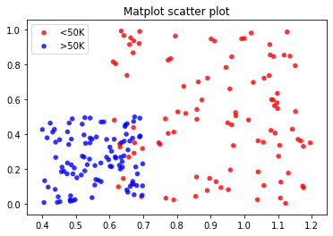

```python
N1 = len(class1data)
N2 = len(class2data)
N = len(feature_data)

mu1 = np.mean(class1data, 0)
mu2 = np.mean(class2data, 0)

print(mu1)
print(mu2)

Sigma1 = np.cov(class1data.T)
Sigma2 = np.cov(class2data.T)


prior1 = N1 / N
prior2 = N2 / N

## now compute the discriminant function on test data

xs, ys = np.meshgrid(np.linspace(-3,6, 500), np.linspace(-3,7, 500))

# Xtest = np.vstack((X_test, T_test)).T
XtestS = normalize(X_test)
d1 = QDA(XtestS, mu1, Sigma1, prior1)
d2 = QDA(XtestS, mu2, Sigma2, prior2)
print(d1)
print(d2)
scattermethod(X=d1, Y=d2, N=100)
```

#### Testing Linear Discriminant Analysis

[output not shown]

[output cut: 21 more lines]

```
 -14.33736399 -17.80801067   2.41154658 -17.80801067  -1.0591001
  -1.0591001   -0.19143843 -17.80801067 -16.07268733  -1.0591001
  -0.19143843   3.27920825  -5.39740846   0.67622324 -17.80801067
 -17.80801067 -16.940349     3.27920825 -17.80801067  -0.19143843
 -17.80801067  -1.0591001   -1.0591001   -3.66208512   3.27920825
 -16.07268733 -15.20502566 -16.940349   -17.80801067 -17.80801067
 -17.80801067 -17.80801067 -16.940349   -16.940349     2.41154658
 -16.940349   -12.60204065  -0.19143843 -16.940349     2.41154658
  -1.0591001    2.41154658   2.41154658  -0.19143843 -16.940349
   2.41154658  -1.92676177 -16.07268733   3.27920825  -1.0591001
  -1.0591001   -1.0591001   -1.0591001  -15.20502566  -0.19143843
 -16.940349     4.14686992  -1.92676177   2.41154658 -15.20502566
 -14.33736399  -1.0591001   -1.0591001    5.01453159 -19.54333402
 -16.940349   -14.33736399 -14.33736399  -1.0591001    0.67622324
 -14.33736399 -17.80801067  -1.0591001   -0.19143843  -0.19143843]
```

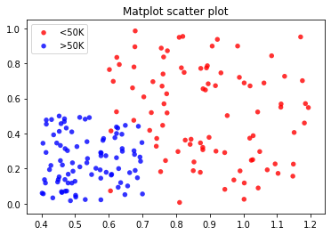

```python
N1 = len(class1data)
N2 = len(class2data)
N = len(feature_data)
#ldafeatures[labels==i]
# means, stds = np.mean(Xtrain, 0), np.std(Xtrain, 0)
# Xs = (Xtrain - means) / stds

mu1 = np.mean(class1data, 0)
mu2 = np.mean(class2data, 0)

print(mu1)
print(mu2)

Sigma1 = np.cov(class1data.T)
Sigma2 = np.cov(class2data.T)


prior1 = N1 / N
prior2 = N2 / N

## now compute the discriminant function on test data

# xs, ys = np.meshgrid(np.linspace(-3,6, 500), np.linspace(-3,7, 500))

# Xtest = np.vstack((X_test, T_test)).T
XtestS = normalize(X_test)
d1 = LDA(XtestS, mu1, Sigma1, prior1)
d2 = LDA(XtestS, mu2, Sigma2, prior2)

# Printing decision boundaries
print(d1)
print(d2)
scattermethod(X=d1, Y=d2, N=90)
```

```python
xs, ys = np.meshgrid(np.linspace(-3,6, 100), np.linspace(-3,7, 100))
```

#### Testing Logistic Regression

```python
lr_model = LogisticRegression(lr=0.01, num_iter=10000)
lr_model.fit(X_train, T_train)
```

```python
pred = lr_model.predict(X_test)
```

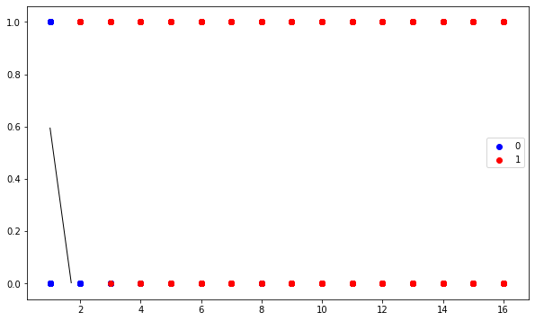

```python
plt.figure(figsize=(10, 6))
plt.scatter(X[T == 0][:, 0], X[T == 0][:, 1], color='b', label='0')
plt.scatter(X[T == 1][:, 0], X[T == 1][:, 1], color='r', label='1')
plt.legend()
x1_min, x1_max = X_test[:,0].min(), X_test[:,0].max(),
x2_min, x2_max = X_test[:,1].min(), X_test[:,1].max(),
xx1, xx2 = np.meshgrid(np.linspace(x1_min, x1_max), np.linspace(x2_min, x2_max))
grid = np.c_[xx1.ravel(), xx2.ravel()]
probs = lr_model.predict_prob(grid).reshape(xx1.shape)
plt.contour(xx1, xx2, probs, [0.5], linewidths=1, colors='black');
```

```python
score = 0
for i in range(len(pred)):
    if pred[i] == T_test[i]:
        score +=1

print(score)
print(len(pred))

print("Accuracy : %s"%str(score*100/len(pred)) + "%")
```

```
57
200
Accuracy : 28.5%
```

#### Testing Pocket Algorithm

```python
po_model = PocketAlgo(alpha=0.1, maxiter=1000)
w = po_model.train(X_train, T_train)
```

```python
T_train.shape
```

```
(800,)
```

```python
pred = po_model.use(X_test, w)

score = 0
for i in range(len(pred)):
    if pred[i] == T_test[i]:
        score +=1

print(score)
print(len(pred))

print("Accuracy : %s"%str(score*100/len(pred)) + "%")
```

```
143
200
Accuracy : 71.5%
```

## Discussions about classificaion model comparison

Linear Discriminate Analysis (LDA) and Quadratic Discriminate Analysis (QDA) can be used in this case. When the dimensionality is high, we apply say LDA to our data, and by this we take into consideration different possible relations to our data using the different matrix operations like covariance and mean. Alongside the scatter matrices, these give a good idea about the data using the following eigenvalue and its corresponding eigenvector. We take the highest eigenvalue, and we notice that when the eigenvalue is high enough, the more information about the data that we have. In LDA, we convert the larger dimension data set into a linear dimension we have to identify the best possible features using the above-mentioned process and thereby get the best possible results. This won’t work very well when the data which cannot be easily linearly separable or even for smaller clearly visible data sets, for which logistic regression with sigmoid function could be the best solution for.

# Conclusions

Summarize your work here. Which classifier do you think the best? Discuss the challenges or somethat that you learned. If you have any suggestion about the assignment, you can write about it.

So far, I have taken dataset and performed preliminary analysis on it to understand what the dataset is about and what it is trying to convey by analysing several parameters that contribute to the target variable.

To understand classficiation I have implemented the classfication algorithms using 4 different techniques i.e. Pocket Algorithm, Quadratic Discriminant Analysis, Linear Discriminant Analysis and Logistic Regression.

From the algorithms tested so far, pocket algorithm is the simplest Algorithms but it is also the slowest. It took the most time despite reducing the size of the data.

Logistic Regression so far is the quickest way to classify the data but as per this dataset it shows very little accuracy.

The challenging part about this assignment was the implementation strategies for QDA and LDA since the way the formulas are derieved made it seem a bit complicated. The way data is classified using standard classification algorithms like the one from SciKit package was interesting to learn

# References

List all your references here.

1. Pocket Algorithm for training Perceptrons - Stackoverflow https://stats.stackexchange.com/questions/51200/pocket-algorithm-for-training-perceptrons
2. Quadratic Discriminant Analysis - Rapidminer Studio Documentation https://docs.rapidminer.com/latest/studio/operators/modeling/predictive/discriminant_analysis/quadratic_discriminant_analysis.html
3. Linear Discriminant Analysis - Rapidminer Studio Documentation https://docs.rapidminer.com/latest/studio/operators/modeling/predictive/discriminant_analysis/linear_discriminant_analysis.html
4. Logistic Regression from Scratch - Medium https://medium.com/@martinpella/logistic-regression-from-scratch-in-python-124c5636b8ac
5. Adult Census Dataset - UCI https://archive.ics.uci.edu/ml/datasets/Census+Income

# Extra Credit

- [OPT 1] Search for a ordinal data set and apply your classifiers to it.
  - Repeat the experiments on it.
  - Do you have different observation from previous results?
  - Were you able to observe that we discussed in class about logistic regression?
  - For a full extra credit point, you need to discuss all bullet points in Results section.
- [OPT 2] Partition your data into five sets. Selecting one test set and the other for training, repeat your experiments and observe/analyze the 5 different training/testing errors.

## Grading

DO NOT forget to submit your data! Your notebook is supposed to run well after running your codes.

To help our TA's grading, please make an explicit section for each grading criteria.

**Note: this is a WRITING assignment. Proper writing is REQUIRED. Comments are not considered as writing.**

| points |  | description |
| --- | --- | --- |
| 5 | Overview | states the objective and the appraoch |
| 15 | Data |  |
|  | 5 | description |
|  | 5 | plots for understanding or analysis |
|  | 5 | preliminary observation |
| 25 | Methods |  |
|  | 10 | Summary of Classification models |
|  | 5 | Explanation of codes |
|  | 10 | Pocket, LDA, QDA, Logistic Regression |
| 40 | Experiments |  |
|  | 5 | Discussion about evaluation metrics |
|  | 5 | Discussion about train and test accuracies |
|  | 20 | plots for results (5 for each algorithm) |
|  | 10 | Discussions about classificaion model comparison |
| 5 |  | Conclusions |
| 5 |  | Referemces |
| 5 |  | Grammar and spelling error (Proofread please) |